# Technical Exercise for Program Officer Candidate; Verra Technology Solutions

SMurphy 2023-12-04

- Task 1
- 1.1 Import Data
- 1.2 Audit Data
- 1.3 Tidy Data
- 2.1 Compute Biomass at Plot Level (Eq1)
- 2.2 Compute Biomass at Strata Level (Eq2)
- 2.3 Compute Carbon in Harvested Volumes (Eq3)
- 2.4 Compute Carbon in Extracted Volumes (Eq4)
- 3.1 Additional Metrics
- 3.2 Regression Diagnostics
- Appendix I: Codebook Derived
- Task 2

## Task 1

**Prototype Tool for Quantifying GHG in Standing Timber Using VSC-Methodology-VM0010**

The following workflow was used to test a prototype tool for quantifying greenhouse gas (GHG) emissions reduction. The objective is to illustrate the process outlined in the VCS Methodology, specifically VM0010, with an emphasis on simplicity of tool design over burdensome complexity. The chosen subsection for digitalization is “8.1.1 Calculation of carbon stocks in commercial timber volumes”.

A number of empricial assumptions were made including sourcing of pre-existing inventory dataset with pre-defined format and values published in the exercise’s document (‘Program Officer Technology Solutions Seamus Murphy’). Using this table of observations, an excel spreadsheet was copied into and imported into an R environment as the dataframe ’`dataset_raw'` and commited to the project’s github repository [here](https://github.com/seamusrobertmurphy/verra-tasks1-2). In this original, unchanged dataset, assumptions of values can be viewed regarding sample strata, plot, species, tree, volume, species wood characteristics, and plot area.

The following table presents a data dictionary of these values, along with descriptions of their units, variable labels, types and file structure. Documentation of the dataset as it was received in original format ‘`dataset_raw.xlsx`’ and descriptions of output dataset ’`dataset_tidy.xlsx'` are intended to enable reproducability, encourage collaboration and inform future procedures for data submissions from clients.

[output not shown]

## 1.1 Import Data

Import `dataset_raw` and write copy to `dataset_tidy`. Seed is set to `77777`.

```r
set.seed(77777)
dataset_raw <- read_excel("dataset_raw.xlsx")
write.csv(dataset_raw, "dataset_tidy.csv", row.names = FALSE)
dataset_tidy <- read.csv("dataset_tidy.csv")
dataset_tidy
```

```
# A tibble: 10 × 5
   Stratum...i. Plot..sp. Species..j. Tree..l. Volume..V_.l.j.I.sp..
          <int>     <int> <chr>       <chr>                    <dbl>
 1            1         1 Sp1         t1                        3.3
 2            1         1 Sp1         t2                        4.8
 3            1         1 Sp1         t3                        4.08
 4            1         2 Sp4         t1                        1.5
 5            1         2 Sp4         t2                        1.68
 6            2         1 Sp1         t1                        1.38
 7            2         1 Sp2         t2                        3.24
 8            2         1 Sp3         t3                        3.72
 9            2         1 sp4         t4                        2.94
10            2         1 Sp5         t5                        3.36
```

## 1.2 Audit Data

Examine structure, scan for errors, and save audit report for input to codebook (Appendix I).

```r
str(dataset_tidy)
dplyr::count(dataset_tidy, Species..j.)

saveHTML(dataMaid::makeDataReport(
  dataset_tidy,
  output = "html",
  codebook = TRUE,
  onlyProblematic = TRUE,
  visuals = setVisuals(all = "basicVisual"),
  replace = TRUE
))
```

```
'data.frame':   10 obs. of  5 variables:
 $ Stratum...i.         : int  1 1 1 1 1 2 2 2 2 2
 $ Plot..sp.            : int  1 1 1 2 2 1 1 1 1 1
 $ Species..j.          : chr  "Sp1" "Sp1" "Sp1" "Sp4" ...
 $ Tree..l.             : chr  "t1" "t2" "t3" "t1" ...
 $ Volume..V_.l.j.I.sp..: num  3.3 4.8 4.08 1.5 1.68 1.38 3.24 3.72 2.94 3.36

# A tibble: 6 × 2
  Species..j.     n
  <chr>       <int>
1 Sp1             4
2 Sp2             1
3 Sp3             1
4 Sp4             2
5 Sp5             1
6 sp4             1
```

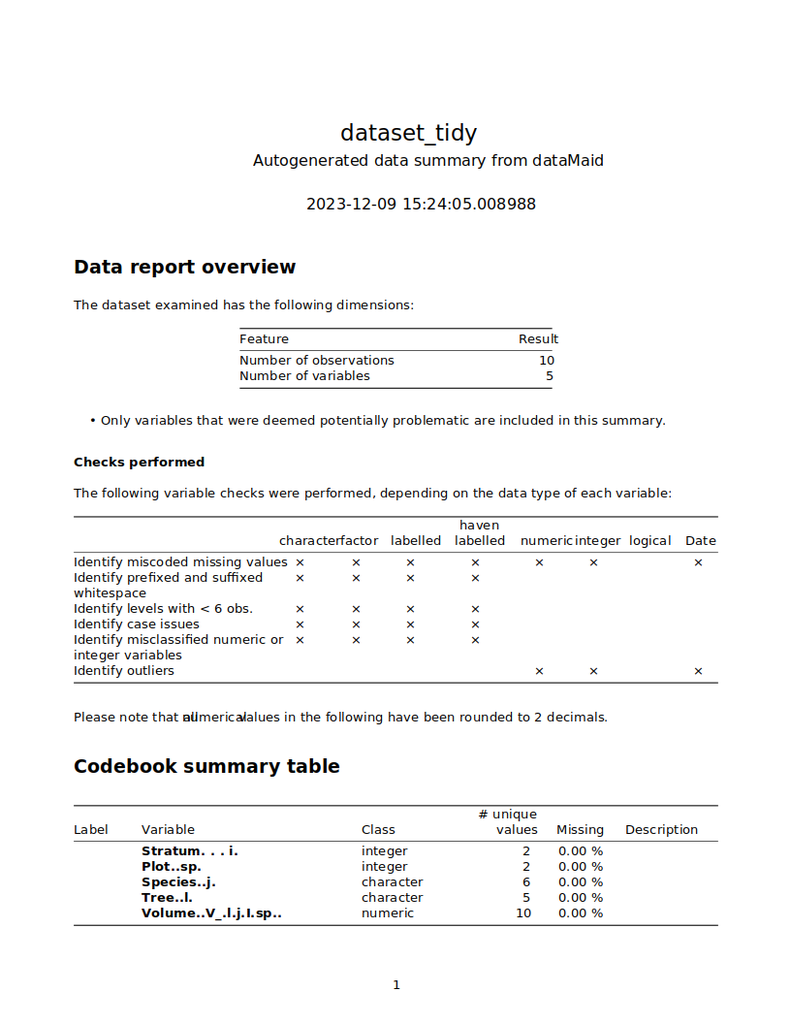

## 1.3 Tidy Data

Tests identified one problematic entry in values of `Species..j.` variable and multiple naming issues inherited during data import. Variable relabelling was carried out according to naming convention stated in exercise document, the symbology used in equations 1-4 of subsection 8.1.1 of the [VM0010 Verra Methodology](https://verra.org/wp-content/uploads/2018/03/VM0010-Methodology-for-IMF-LtPF-v1.3_0.pdf), and syntax standards provided in the [Tidyverse style guide](https://style.tidyverse.org/). This involved the following changes.

- Correct the case-sensitive error from `sp4` to `Sp4`.
- Convert or recode variables to reflec their class
- Remove spaces
- Use underscores between words
- Change to lowercase
- Warnings, messages turned to silent
- Space placed after commas
- Max 80 characters to chunks
- Comments limited to single line each
- `::` operator used to signpost installs & avoid package conflicts

```r
data.table::setnames(dataset_tidy, old = "Stratum...i.", new = "stratum_i", skip_absent = TRUE)
data.table::setnames(dataset_tidy, old = "Species..j.", new = "species_j", skip_absent = TRUE)
data.table::setnames(dataset_tidy, old = "Plot..sp.", new = "plot_sp", skip_absent = TRUE)
data.table::setnames(dataset_tidy, old = "Tree..l.", new = "tree_l", skip_absent = TRUE)
data.table::setnames(dataset_tidy, old = "Volume..V_.l.j.I.sp..", new = "volume", skip_absent = TRUE)
dataset_tidy$species_j[dataset_tidy$species_j == "sp4"] <- "Sp4"
dataset_tidy$species_j <- as.factor(dataset_tidy$species_j)
dataset_tidy$stratum_i <- as.factor(dataset_tidy$stratum_i)
```

Derive new variable columns using values provided in the exercise document. Compute additional variables of area estimates at different units and scales:

- `bcef_r`: Biomass expansion factor applicable to wood removals (t.d.m m<sup>-3</sup>).
- `cf`: Carbon fraction of biomass of species (tCt d.m.<sup>-1</sup>)
- `d`: Basic wood density of species (t d.m. m<sup>-3</sup>)
- `a_sp`: Total area of plot in hectares (ha)
- `a_sp_m2`: Total area of plot in metres squared (m<sup>2</sup>)
- `a_I_m2`: Total area of stratum in metres squared (m<sup>2</sup>)
- `a_I_ha`: Total area of stratum in hectares (ha)

Tabulate, confirm and write to directory.

```r
dataset_tidy$bcef_r <- 0.7
dataset_tidy$cf <- 0.5
dataset_tidy$d <- 0.5
dataset_tidy$a_sp <- 0.1
dataset_tidy$a_sp_m2 <- dataset_tidy$a_sp * 10000

dataset_tidy <- dataset_tidy %>%
  group_by(stratum_i) %>%
  mutate(a_I_m2 = sum(a_sp_m2), a_I_ha = sum(a_sp))

dataset_tidy
```

```
# A tibble: 10 × 12
   stratum_i plot_sp species_j tree_l volume bcef_r    cf     d  a_sp a_sp_m2
   <fct>       <int> <fct>     <chr>   <dbl>  <dbl> <dbl> <dbl> <dbl>   <dbl>
 1 1               1 Sp1       t1       3.3     0.7   0.5   0.5   0.1    1000
 2 1               1 Sp1       t2       4.8     0.7   0.5   0.5   0.1    1000
 3 1               1 Sp1       t3       4.08    0.7   0.5   0.5   0.1    1000
 4 1               2 Sp4       t1       1.5     0.7   0.5   0.5   0.1    1000
 5 1               2 Sp4       t2       1.68    0.7   0.5   0.5   0.1    1000
 6 2               1 Sp1       t1       1.38    0.7   0.5   0.5   0.1    1000
 7 2               1 Sp2       t2       3.24    0.7   0.5   0.5   0.1    1000
 8 2               1 Sp3       t3       3.72    0.7   0.5   0.5   0.1    1000
 9 2               1 Sp4       t4       2.94    0.7   0.5   0.5   0.1    1000
10 2               1 Sp5       t5       3.36    0.7   0.5   0.5   0.1    1000
# ℹ 2 more variables: a_I_m2 <dbl>, a_I_ha <dbl>
```

```r
write.csv(dataset_tidy, "dataset_tidy.csv", row.names = FALSE)
```

## 2.1 Compute Biomass at Plot Level (Eq1)

Note all four equations that follow derive estimates according to specific species, whether measured at the plot level, stratum or globally. Hence, caution is advised when computing initial, absolute estimates and when deriving or applying hectare expansion factors.

On page 19 of the VM0010 Methodology, ‘equation 1’ provides calculation of merchantable timber volume of a species at the plot level. This is estimated in m<sup>3</sup> as follows:

$V_{j,i|BSL} = \sum_{l = 1}^{L} V_{l,j,i,sp}$

where $V_{j,i|BSL}$ refers to the **sum** of merchantable volume of species *j* from plot *sp* in stratum *i.* For this, we run the following:

```r
dataset_tidy <- dataset_tidy %>%
  group_by(species_j, stratum_i, plot_sp) %>%
  mutate(vji_sp_m3 = sum(volume))

data.table::setDT(dataset_tidy)[, .(
  vji_sp_m3 = sum(volume)
),
by = .(stratum_i, plot_sp, species_j)
]
```

```
# A tibble: 7 × 4
  stratum_i plot_sp species_j vji_sp_m3
  <fct>       <int> <fct>         <dbl>
1 1               1 Sp1           12.2
2 1               2 Sp4            3.18
3 2               1 Sp1            1.38
4 2               1 Sp2            3.24
5 2               1 Sp3            3.72
6 2               1 Sp4            2.94
7 2               1 Sp5            3.36
```

## 2.2 Compute Biomass at Strata Level (Eq2)

On page 19 of the VM0010 Methodology, ‘equation 2’ provides calculation of merchantable timber volume of a species at the stratum level:

$V_{j,i|BSL} = \displaystyle \frac{1}{SP} \sum_{sp=1}^{sp} \displaystyle \frac{V_{j,i,sp}}{A_{sp}}$

where $V_{j,i|BSL}$ refers to the **mean** merchantable timber volume of species *j* measured across all plots within stratum *i*. Volume estimates are derived in terms of m<sup>3</sup>/ha<sup>-1</sup> using an expansion factor derived as the ratio of plot area 1,000m<sup>2</sup> to 10,000m<sup>2</sup>, as follows.

```r
dataset_tidy <- dataset_tidy %>%
  group_by(stratum_i, species_j) %>%
  mutate(vji_ha_m3 = mean(vji_sp_m3) * 10)

data.table::setDT(dataset_tidy)[, .(
  vji_sp_m3,
  vji_ha_m3 = mean(vji_sp_m3) * 10
),
by = .(stratum_i, species_j)
]
```

```
# A tibble: 10 × 4
   stratum_i species_j vji_sp_m3 vji_ha_m3
   <fct>     <fct>         <dbl>     <dbl>
 1 1         Sp1           12.2      122.
 2 1         Sp1           12.2      122.
 3 1         Sp1           12.2      122.
 4 1         Sp4            3.18      31.8
 5 1         Sp4            3.18      31.8
 6 2         Sp1            1.38      13.8
 7 2         Sp2            3.24      32.4
 8 2         Sp3            3.72      37.2
 9 2         Sp4            2.94      29.4
10 2         Sp5            3.36      33.6
```

## 2.3 Compute Carbon in Harvested Volumes (Eq3)

On page 20 of the VM0010 Methodology, ‘equation 3’ provides calculation of carbon stock of harvested timber volumes for species *i* in stratum *i*.

In the absence of harvest plan data, carbon stocks of commercial timber will be derived from the full inventory `dataset_tidy`.

This differs to ‘equation 3’ below, which measures mean carbon stock from volumes of ‘harvested biomass’ $C_{HB,j,i|BSL}$ comprised of volumes estimates from extracted timber that is destined off-site for market sales, in addition to volume estimates from extracted timber that is remaining on-site due to damage or use during site operations and road construction. The difference in destinations of these carbon stocks means that alternative carbon factors must be applied in their calculation, as indicated in following two equations

$C_{HB,j,i|BSL} = (V_{EX,j,i|BSL} + V_{EX,INF,j,i|BSL} ) * BCEF_{R} * CF_{j}$

Carbon estimates are calculated in units of metric tons per hectare (tC/ha<sup>-1</sup>) by multiplying mean volume per hectare of extracted timber of species *i* from stratum *j* by the carbon fraction $CF$ and biomass conversion and expansion factor $BCEF_{R}$ of that species.

```r
dataset_tidy <- dataset_tidy %>%
  mutate(chb_ha_tC = vji_ha_m3 * bcef_r * cf)

data.table::setDT(dataset_tidy)[, .(
  vji_sp_m3,
  vji_ha_m3,
  chb_ha_tC = vji_ha_m3 * bcef_r * cf
),
by = .(stratum_i, species_j)
]
```

```
# A tibble: 10 × 5
   stratum_i species_j vji_sp_m3 vji_ha_m3 chb_ha_tC
   <fct>     <fct>         <dbl>     <dbl>     <dbl>
 1 1         Sp1           12.2      122.      42.6
 2 1         Sp1           12.2      122.      42.6
 3 1         Sp1           12.2      122.      42.6
 4 1         Sp4            3.18      31.8     11.1
 5 1         Sp4            3.18      31.8     11.1
 6 2         Sp1            1.38      13.8      4.83
 7 2         Sp2            3.24      32.4     11.3
 8 2         Sp3            3.72      37.2     13.0
 9 2         Sp4            2.94      29.4     10.3
10 2         Sp5            3.36      33.6     11.8
```

## 2.4 Compute Carbon in Extracted Volumes (Eq4)

On page 21 of the VM0010 Methodology, ‘equation 4’ provides calculation of mean estimates of carbon stocks of species *i* in stratum *j,* by multiplying the species’ value of basic wood density $D$ by its carbon fraction $CF$ by its mean volume of extracted biomass per hectare. Estimates of carbon stocks are derived in terms of metric tons per hectare tC.ha<sup>-1</sup> using the following formula:

$C_{EX,j,i|BSL} = (V_{EX,j,i|BSL} + V_{EX,INF,j,i|BSL} ) * D_{j} * CF_{j}$

```r
dataset_tidy <- dataset_tidy %>%
  mutate(cex_ha_tC = vji_ha_m3 * d * cf)

data.table::setDT(dataset_tidy)[, .(
  vji_sp_m3,
  vji_ha_m3,
  chb_ha_tC,
  cex_ha_tC = vji_ha_m3 * d * cf
),
by = .(stratum_i, species_j)
]
```

```
# A tibble: 10 × 6
   stratum_i species_j vji_sp_m3 vji_ha_m3 chb_ha_tC cex_ha_tC
   <fct>     <fct>         <dbl>     <dbl>     <dbl>     <dbl>
 1 1         Sp1           12.2      122.      42.6      30.4
 2 1         Sp1           12.2      122.      42.6      30.4
 3 1         Sp1           12.2      122.      42.6      30.4
 4 1         Sp4            3.18      31.8     11.1       7.95
 5 1         Sp4            3.18      31.8     11.1       7.95
 6 2         Sp1            1.38      13.8      4.83      3.45
 7 2         Sp2            3.24      32.4     11.3       8.1
 8 2         Sp3            3.72      37.2     13.0       9.3
 9 2         Sp4            2.94      29.4     10.3       7.35
10 2         Sp5            3.36      33.6     11.8       8.4
```

## 3.1 Additional Metrics

```r
# vJ_ha_m3: Mean volume by species across strata (m^3.ha-1)
dataset_tidy <- dataset_tidy %>%
  group_by(species_j) %>%
  mutate(vJ_ha_m3 = mean(vji_sp_m3) * 10)
dataset_tidy[1:10, ] %>%
  select(
    stratum_i, species_j,
    plot_sp, vji_ha_m3,
    chb_ha_tC, cex_ha_tC,
    vJ_ha_m3
  ) %>%
  kbl(caption = "Table with right-hand showing mean biomass volume per species across all strata (m3.ha-1)", escape = T) %>%
  kable_minimal(full_width = T)
```

Table with right-hand showing mean biomass volume per species across all strata (m3.ha-1)

| stratum_i | species_j | plot_sp | vji_ha_m3 | chb_ha_tC | cex_ha_tC | vJ_ha_m3 |
| --- | --- | --- | --- | --- | --- | --- |
| 1 | Sp1 | 1 | 121.8 | 42.63 | 30.45 | 94.8 |
| 1 | Sp1 | 1 | 121.8 | 42.63 | 30.45 | 94.8 |
| 1 | Sp1 | 1 | 121.8 | 42.63 | 30.45 | 94.8 |
| 1 | Sp4 | 2 | 31.8 | 11.13 | 7.95 | 31.0 |
| 1 | Sp4 | 2 | 31.8 | 11.13 | 7.95 | 31.0 |
| 2 | Sp1 | 1 | 13.8 | 4.83 | 3.45 | 94.8 |
| 2 | Sp2 | 1 | 32.4 | 11.34 | 8.10 | 32.4 |
| 2 | Sp3 | 1 | 37.2 | 13.02 | 9.30 | 37.2 |
| 2 | Sp4 | 1 | 29.4 | 10.29 | 7.35 | 31.0 |
| 2 | Sp5 | 1 | 33.6 | 11.76 | 8.40 | 33.6 |

```r
# VI_ha_m3: Mean volume by strata across species and plots (m^3.ha-1)
dataset_tidy <- dataset_tidy %>%
  group_by(stratum_i) %>%
  mutate(vI_ha_m3 = mean(vji_sp_m3) * 10)
dataset_tidy[1:10, ] %>%
  select(
    stratum_i, species_j,
    plot_sp, vji_ha_m3,
    chb_ha_tC, cex_ha_tC,
    vJ_ha_m3, vI_ha_m3
  ) %>%
  kbl(caption = "Table with right-hand column showing mean biomass volume per strata across all species and plots (m3.ha-1)", escape = T) %>%
  kable_minimal(full_width = T)
```

Table with right-hand column showing mean biomass volume per strata across all species and plots (m3.ha-1)

| stratum_i | species_j | plot_sp | vji_ha_m3 | chb_ha_tC | cex_ha_tC | vJ_ha_m3 | vI_ha_m3 |
| --- | --- | --- | --- | --- | --- | --- | --- |
| 1 | Sp1 | 1 | 121.8 | 42.63 | 30.45 | 94.8 | 85.80 |
| 1 | Sp1 | 1 | 121.8 | 42.63 | 30.45 | 94.8 | 85.80 |
| 1 | Sp1 | 1 | 121.8 | 42.63 | 30.45 | 94.8 | 85.80 |
| 1 | Sp4 | 2 | 31.8 | 11.13 | 7.95 | 31.0 | 85.80 |
| 1 | Sp4 | 2 | 31.8 | 11.13 | 7.95 | 31.0 | 85.80 |
| 2 | Sp1 | 1 | 13.8 | 4.83 | 3.45 | 94.8 | 29.28 |
| 2 | Sp2 | 1 | 32.4 | 11.34 | 8.10 | 32.4 | 29.28 |
| 2 | Sp3 | 1 | 37.2 | 13.02 | 9.30 | 37.2 | 29.28 |
| 2 | Sp4 | 1 | 29.4 | 10.29 | 7.35 | 31.0 | 29.28 |
| 2 | Sp5 | 1 | 33.6 | 11.76 | 8.40 | 33.6 | 29.28 |

```r
# Vsp_ha_n3: Total volume per plot (m^3.ha-1)
dataset_tidy <- dataset_tidy %>%
  group_by(plot_sp, stratum_i) %>%
  mutate(Vsp_ha_m3 = sum(volume) * 10)
dataset_tidy[1:10, ] %>%
  select(
    stratum_i,
    plot_sp, vji_ha_m3,
    chb_ha_tC, cex_ha_tC,
    vJ_ha_m3, vI_ha_m3,
    vI_ha_m3, Vsp_ha_m3
  ) %>%
  kbl(caption = "Table with right-hand column showing total biomass per plot across species (m3.ha-1)", escape = T) %>%
  kable_minimal(full_width = T)
```

Table with right-hand column showing total biomass per plot across species (m3.ha-1)

| stratum_i | plot_sp | vji_ha_m3 | chb_ha_tC | cex_ha_tC | vJ_ha_m3 | vI_ha_m3 | Vsp_ha_m3 |
| --- | --- | --- | --- | --- | --- | --- | --- |
| 1 | 1 | 121.8 | 42.63 | 30.45 | 94.8 | 85.80 | 121.8 |
| 1 | 1 | 121.8 | 42.63 | 30.45 | 94.8 | 85.80 | 121.8 |
| 1 | 1 | 121.8 | 42.63 | 30.45 | 94.8 | 85.80 | 121.8 |
| 1 | 2 | 31.8 | 11.13 | 7.95 | 31.0 | 85.80 | 31.8 |
| 1 | 2 | 31.8 | 11.13 | 7.95 | 31.0 | 85.80 | 31.8 |
| 2 | 1 | 13.8 | 4.83 | 3.45 | 94.8 | 29.28 | 146.4 |
| 2 | 1 | 32.4 | 11.34 | 8.10 | 32.4 | 29.28 | 146.4 |
| 2 | 1 | 37.2 | 13.02 | 9.30 | 37.2 | 29.28 | 146.4 |
| 2 | 1 | 29.4 | 10.29 | 7.35 | 31.0 | 29.28 | 146.4 |
| 2 | 1 | 33.6 | 11.76 | 8.40 | 33.6 | 29.28 | 146.4 |

```r
# Save output dataset
write.csv(dataset_tidy, "dataset_tidy.csv", row.names = FALSE)
```

## 3.2 Regression Diagnostics

Candidate models were then trained, tuned, and analysed using the 10k-fold cross-validation technique (10-repeat). This method was used to present proposed estimates of model bias between training sample and test sample for potential use in actual biomass estimation. It was also used to explore levels of precision in terms of the variation of results (RMSE). Using DescTools package in R, Theil’s U estimate of error also examined level of unexplained variance in each model.

This stage was specifically focused around a diagnostic exercise, reporting on techniques used in cross validation, tuning functions, and predictor evaluation. For quicker review, sample results from the following code chunks were gathered and presented in the three tables directly below.

| **Variable** | **Mean** | **Std. Deviation** | **Std. Error** | **Skewness** | **Shapiro-Wilk** |
| --- | --- | --- | --- | --- | --- |
| stratum_i | 1.5 | 0.53 | 0.17 | 0.00 | *** |
| species_j | 2.60 | 1.58 | 0.50 | 0.14 | * |
| volume | 3.00 | 1.15 | 0.36 | 0.36 |  |
| vji_ha_m3 | 57.54 | 44.77 | 14.16 | 0.69 | *** |

[output not shown]

[output not shown]

An additional set of packages used in this stage were loaded as listed in the `requirements` variable below.

```r
requirements <- install.packages(
  c(
    "oslrr", "ggplot2", "autoplotly", "BiocManager", "ggbio",
    "car", "psych", "useful", "caret",
    "BIOMASS", "rvest", "lmfor", "DescTools",
    "MLmetrics", "knitr", "phyloseq", "carData"
  ),
  dependencies = TRUE
)
requirements
```

```r
# str(dataset_tidy)
dataset_tidy$stratum_i <- as.integer(dataset_tidy$stratum_i)
dataset_tidy$species_j <- as.integer(dataset_tidy$species_j)
model_lm1 <- lm(vji_ha_m3 ~ volume + species_j + stratum_i, data = dataset_tidy)
olsrr::ols_regress(vji_ha_m3 ~ volume + species_j + stratum_i, data = dataset_tidy)
```

```
                         Model Summary
---------------------------------------------------------------
R                       0.968       RMSE                13.706
R-Squared               0.938       Coef. Var           23.820
Adj. R-Squared          0.906       MSE                187.853
Pred R-Squared          0.848       MAE                  9.281
---------------------------------------------------------------
 RMSE: Root Mean Square Error
 MSE: Mean Square Error
 MAE: Mean Absolute Error

                               ANOVA
--------------------------------------------------------------------
                 Sum of
                Squares       DF    Mean Square      F         Sig.
--------------------------------------------------------------------
Regression    16909.928        3       5636.643    30.006     5e-04
Residual       1127.116        6        187.853
Total         18037.044        9
--------------------------------------------------------------------

                                    Parameter Estimates
-------------------------------------------------------------------------------------------
      model       Beta    Std. Error    Std. Beta      t        Sig       lower      upper
-------------------------------------------------------------------------------------------
(Intercept)     84.003        20.840                  4.031    0.007     33.008    134.997
     volume     21.765         4.239        0.557     5.135    0.002     11.393     32.138
  species_j     -8.343         3.189       -0.294    -2.616    0.040    -16.145     -0.540
  stratum_i    -46.712         8.999       -0.550    -5.191    0.002    -68.731    -24.692
-------------------------------------------------------------------------------------------
```

```r
# psych::describe(dataset_tidy$vji_ha_m3)
# psych::describe(dataset_tidy$volume)
# psych::describe(dataset_tidy$species_j)
# psych::describe(dataset_tidy$stratum_i)

shapiro.test(dataset_tidy$stratum_i)
```

```
    Shapiro-Wilk normality test

data:  dataset_tidy$stratum_i
W = 0.65527, p-value = 0.000254
```

```r
shapiro.test(dataset_tidy$species_j)
```

```
    Shapiro-Wilk normality test

data:  dataset_tidy$species_j
W = 0.83827, p-value = 0.04207
```

```r
shapiro.test(dataset_tidy$volume)
```

```
    Shapiro-Wilk normality test

data:  dataset_tidy$volume
W = 0.9223, p-value = 0.3766
```

```r
shapiro.test(dataset_tidy$vji_ha_m3)
```

```
    Shapiro-Wilk normality test

data:  dataset_tidy$vji_ha_m3
W = 0.69994, p-value = 0.0008795
```

| **Variable** | **Mean** | **SD** | **SE** | **Skewness** | **Shapiro-Wilk** |
| --- | --- | --- | --- | --- | --- |
| stratum_i | 1.5 | 0.53 | 0.17 | 0.00 | *** |
| species_j | 2.60 | 1.58 | 0.50 | 0.14 | * |
| volume | 3.00 | 1.15 | 0.36 | 0.36 |  |
| vji_ha_m3 | 57.54 | 44.77 | 14.16 | 0.69 | *** |

```
-----------------------------------------------
       Test             Statistic       pvalue
-----------------------------------------------
Shapiro-Wilk              0.918          0.3407
Kolmogorov-Smirnov        0.1812         0.8419
Cramer-von Mises          0.8333         0.0048
Anderson-Darling          0.3383         0.4225
-----------------------------------------------


 Breusch Pagan Test for Heteroskedasticity
 -----------------------------------------
 Ho: the variance is constant
 Ha: the variance is not constant

                Data
 -------------------------------------
 Response : vji_ha_m3
 Variables: fitted values of vji_ha_m3

        Test Summary
 ----------------------------
 DF            =    1
 Chi2          =    0.7880034
 Prob > Chi2   =    0.3747045

Tolerance and Variance Inflation Factor
---------------------------------------
  Variables Tolerance      VIF
1    volume 0.8842968 1.130842
2 species_j 0.8247492 1.212490
3 stratum_i 0.9278966 1.077706


Eigenvalue and Condition Index
------------------------------
  Eigenvalue Condition Index    intercept     volume  species_j    stratum_i
1 3.63391993        1.000000 3.184201e-03 0.00687952 0.01296957 6.623171e-03
2 0.25093610        3.805451 4.067109e-03 0.14908146 0.50064841 8.506720e-06
3 0.08426133        6.567098 2.275283e-05 0.26599152 0.32764056 7.126742e-01
4 0.03088264       10.847521 9.927259e-01 0.57804751 0.15874147 2.806942e-01

# A tibble: 1 × 3
  studentized_residual unadjusted_p_val bonferroni_p_val
                 <dbl>            <dbl>            <dbl>
1                 2.41           0.0609            0.609

# A tibble: 3 × 3
  Variables Tolerance   VIF
  <chr>         <dbl> <dbl>
1 volume        0.884  1.13
2 species_j     0.825  1.21
3 stratum_i     0.928  1.08
```

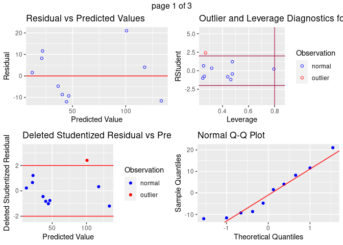

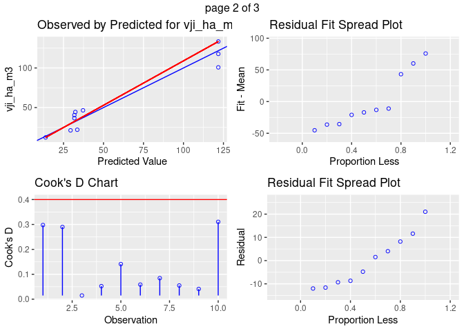

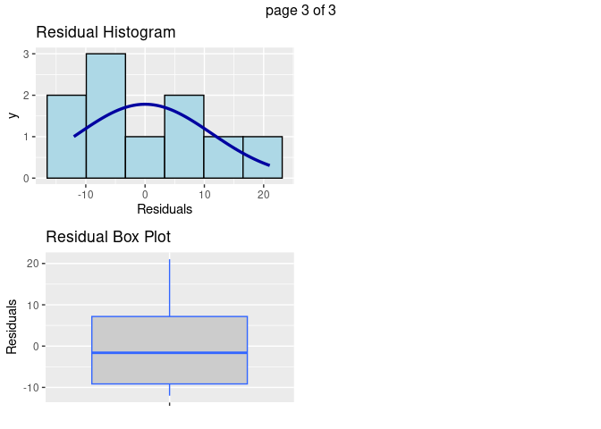

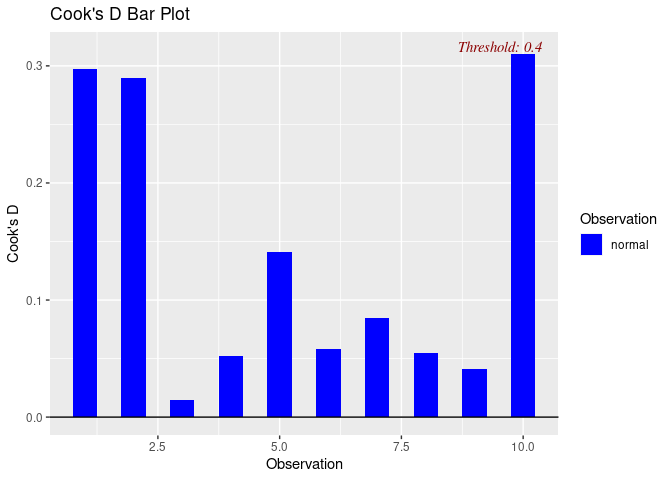

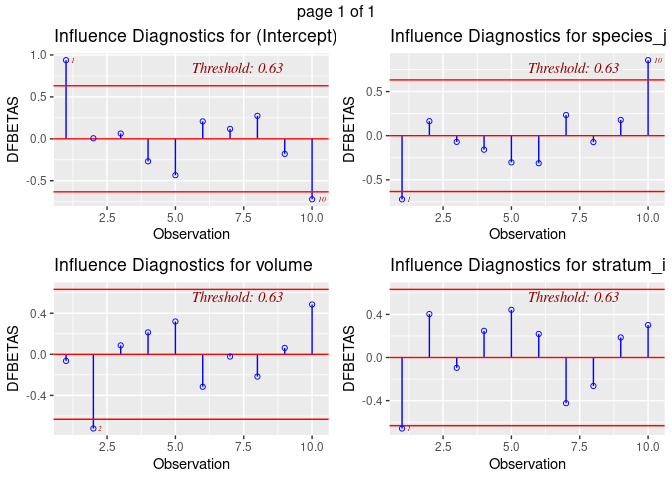

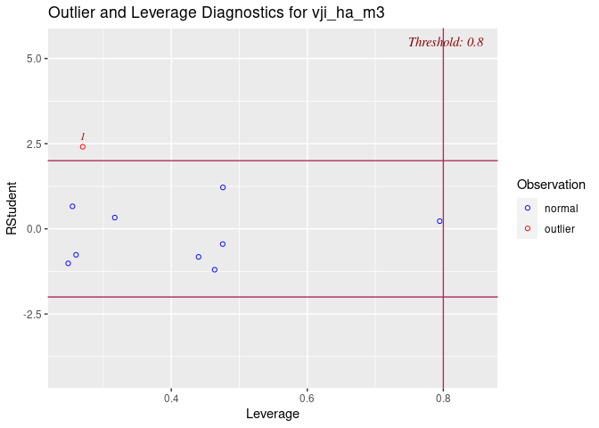

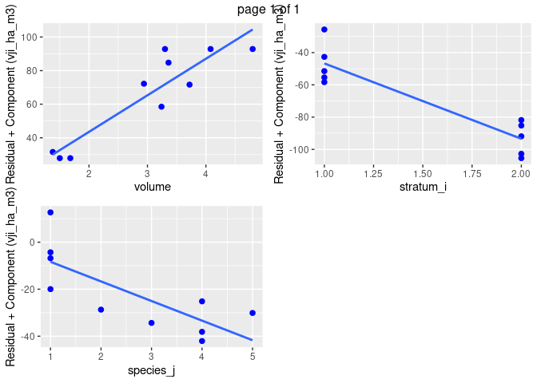

[output not shown]

Comparing model performances using cross validation.

```r
# Split training and test data
dataset_tidy.samples <- createDataPartition(dataset_tidy$vji_ha_m3, p=0.70, list = FALSE)
dataset_tidy.train <- dataset_tidy[dataset_tidy.samples, ]
dataset_tidy.test <- dataset_tidy[-dataset_tidy.samples, ]
```

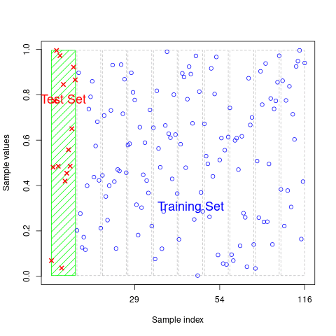

```r
# Set training regime
model_training_10kfold <- trainControl(method = "repeatedcv",
                                       number = 10, repeats = 10)
# animation of 10-kfold method:
knitr::include_graphics(path = "animation.gif")
```

```r
# Train full and test models: support vector machine*linear
svm_linear_train <- train(vji_ha_m3 ~ volume + species_j + stratum_i,
                          data = dataset_tidy.train,
                          method = "svmLinear",
                          trControl = model_training_10kfold,
                          preProcess = c("center", "scale"),
                          tuneLength = 10
                          )

svm_linear_full <- train(vji_ha_m3 ~ volume + species_j + stratum_i,
                          data = dataset_tidy,
                          method = "svmLinear",
                          trControl = model_training_10kfold,
                          preProcess = c("center", "scale"),
                          tuneLength = 10
                          )

# Train full and test models: randomForest regression tree
rf_train <- train(vji_ha_m3 ~ volume + species_j + stratum_i,
                  data = dataset_tidy.train,
                  method = "rf", ntree = 1000,
                  metric = "RMSE",
                  trControl = model_training_10kfold,
                  importance = TRUE
                  )
svm_linear_full_pred <- predict(svm_linear_full, data = dataset_tidy)
svm_linear_full_pred_mae <- mae(svm_linear_full_pred, dataset_tidy$vji_ha_m3)
svm_linear_full_pred_mae
```

```
[1] 9.323846
```

```r
svm_linear_full_pred_rmse <- rmse(svm_linear_full_pred, dataset_tidy$vji_ha_m3)
svm_linear_full_pred_rmse
```

```
[1] 11.5753
```

```r
#TheilU(dataset_tidy$vji_ha_m3, svm_linear_full_pred, type = 2)
TheilU(dataset_tidy$vji_ha_m3, svm_linear_full_pred, type = 1)
```

```
[1] 0.08325566
```

```r
svm_linear_test_pred <- predict(svm_linear_train, data = dataset_tidy.test)
svm_linear_test_pred_mae <- mae(svm_linear_test_pred, dataset_tidy.test$vji_ha_m3)
svm_linear_test_pred_mae
```

```
[1] 56.6754
```

```r
svm_linear_test_pred_rmse <- rmse(svm_linear_test_pred, dataset_tidy.test$vji_ha_m3)
svm_linear_test_pred_rmse
```

```
[1] 66.84399
```

```r
svm_linear_test_pred_rmse / svm_linear_full_pred_rmse
```

```
[1] 5.774708
```

[output not shown]

## Appendix I: Codebook Derived

Output of auto-generated audit also stored in working directory as `dataMaid_dataset_tidy.pdf`

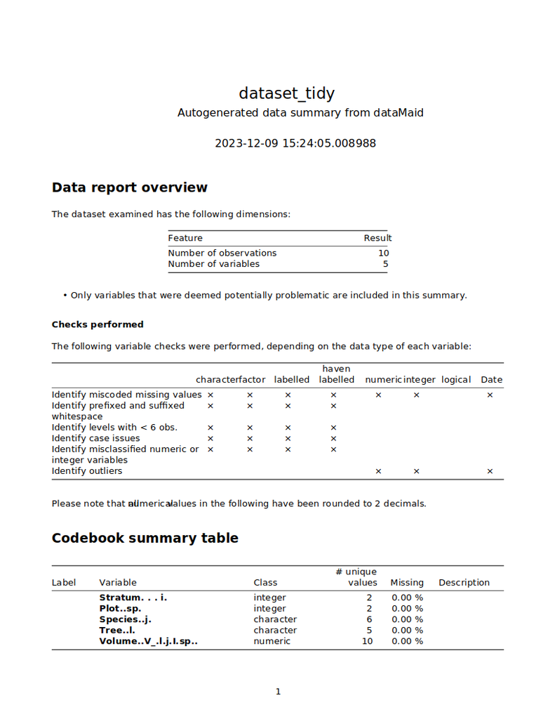

```r
knitr::include_graphics("dataMaid_dataset_tidy.png")
```

# Task 2

Prototype Tool for Mapping Wildfires Using the NASA-FIRMS and Earth-Engine API’s

The digital tool for Task 2 was derived on the Google Colab platform using python programming, a jupyter notebook and the Google Earth Engine library. Using the following link, the tool can be viewed there in its hosted environment with its interactive maps pre-loaded.

The Colab platform should also ensure simpler installation when sharing externally, downloading locally, or running copies in different a Colab project. Note that full editor settings were enabled with this link allowing for code edits to be made by user.

Task 2 Output File Name & Webpage: `verra_task2.ipynb`

- https://colab.research.google.com/drive/11izi_5-iYHOCWHwj17vWxWtlMPbglBiG?usp=sharing

In addition, copies of the Colab notebook were committed to the project’s github repository for easy cloning and revisions:

- https://github.com/seamusrobertmurphy/verra-tasks1-2/blob/main/verra_task2.ipynb